# Your Digest for Tuesday, Mar 26, 2024 11:59 PM

# Diurnal blood pressure variation

#2015MCQ-APR/43

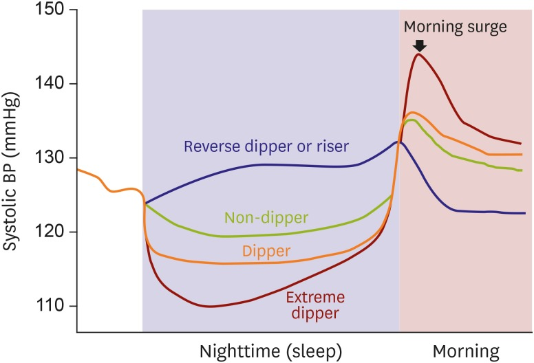

[Source](https://europepmc.org/article/pmc/6713830)

[output not shown]

- **Staggering gait in childhood** (due to *ataxia of all four limbs*) is the main symptom. 4
  - Lower limbs are affected before the upper limbs.

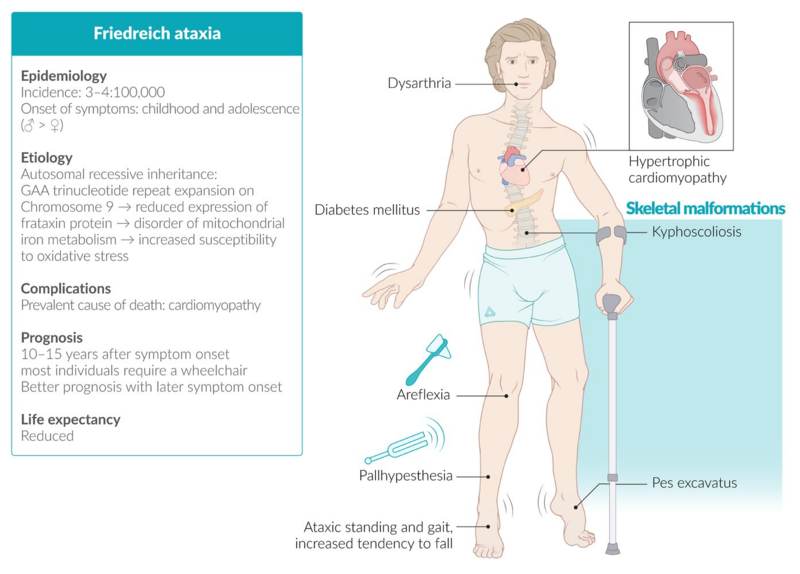

**Diagnosis**:  
Clinical and with detection of expansions of the FXN gene.

⭐15% are SCLC; **85% are NSCLC**.(majority are non-small cell cancers)  
**Adenocarcinoma is commoner** in non smokers and women and in recent times are replaced SQC as the commonest non-small cell lung cancer.

- Typical patient is a **male older than 70**, current or previous smoker.
- SCLC is defined by light microscopy as "tumour with cells which have a small size , scant cytoplasm, absent of inconspicuous nucleoli".
- 90% express TTF-1 which ?can be used for identification.
- Caused by mutations in **TP53** and RB1 genes.
- Occur in central airways causing **symptoms within weeks**.
- Commonly associated with paraneoplastic syndromes.
  1. SIADH - 15 - 40%
  2. Ectopic cushings 5%
  3. Lambert eaton syndrome - 3%

> [!TIP] mnemonic: SEL in small "cell" lung CA  
> **Clubbing**: NSCLC is more commonly associated with clubbing. (35%) compared to only 4% for small cell lung CA. [Source](https://www.news-medical.net/health/Lung-Cancer-and-Nail-Clubbing.aspx)

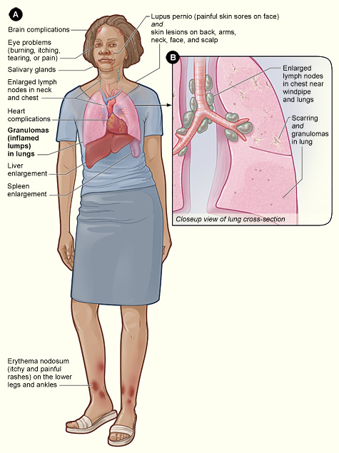

> - It is a **common** ==multisystemic== ==inflammatory== disease that begins more frequently **between 20 and 60 years of age** and represents the **most frequent of all interstitial lung diseases**.
> - The **lungs** are **almost constantly affected** (about 90% of cases) with **bilateral pulmonary hilar lymph node involvement** and possible simultaneous involvement of the lungs.
> - Histopathology features include **noncaseating** epithelioid *granulomas* with tightly packed epithelioid cells, *Langhans* giant cells, and **T lymphocytes**.
- **Lung involvement is commonest** - Histology shows *increased lymphocytes in alveolar walls* and they can also be seen in bonchoalveolar lavage washings.
  - Skin - upto 30% - (lupus pernio, erythema nodosum) and **eye** -5% - (uveitis) are the commonest.
    - [[Sarcoidosis]] is the **commonest cause** of **erythema nodosum**.
- **Hypopituitarism**
- **Hypoadrenalism**
- **Cranial nerves palsies**
- There is also elevated angiotensin converting enzyme levels (which is produced by the granulomas).
- Hypercalcemia, hypercalciuria and elevated alkaline phosphatase.

## Mesangioproliferative glomerulonephritis

[Source](https://www.ncbi.nlm.nih.gov/pmc/articles/PMC5297525/)

#2015MCQ-APR/Q34

- Mesangial cell proliferation and mesangial matrix accumulation are common features in various glomerular disorders.
- Most cases are caused by [[#IgA nephropathy]]
- other causes are
  - IgM nephropathy (IgMN), systemic lupus erythematous (SLE), Alport’s syndrome, resolving phase of post infectious glomerulonephritis and complement nephropathy

> " MPGN may occur in several renal diseases such as IgA nephropathy (commonly), IgM nephropathy, lupus nephritis, and C1q nephropathy". [Source](https://rarediseases.org/gard-rare-disease/mesangial-proliferative-glomerulonephritis/)

[output not shown]

### X-ray changes in rheumatoid arthritis

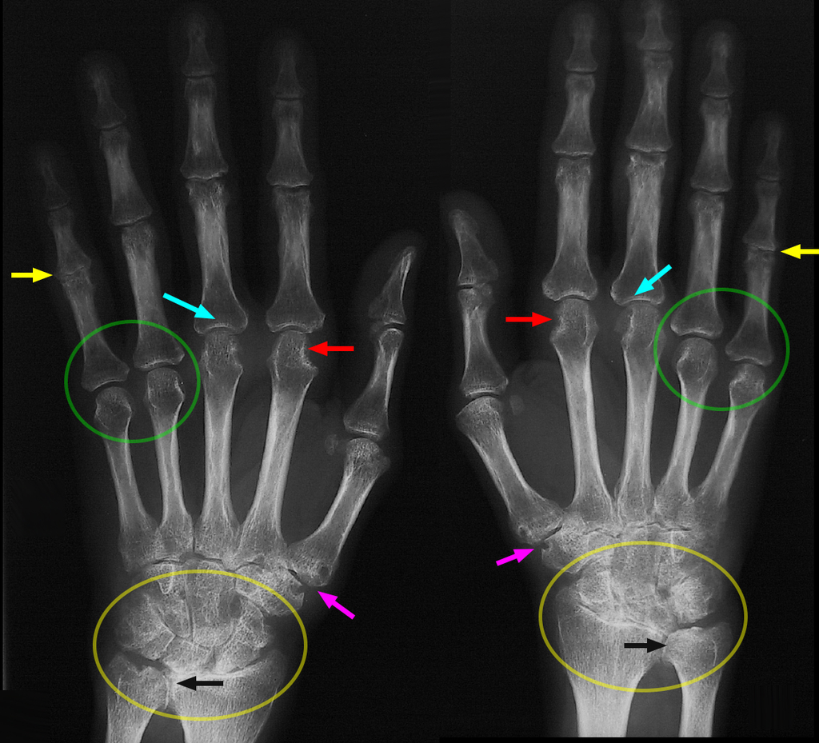

> [Source](https://radiopaedia.org/cases/rheumatoid-arthritis-hands-4#image-52394447)
> - bilateral and symmetrical involvement
> - proximal interphalangeal joint space narrowing (yellow arrows)
> - metacarpophalangeal joint space narrowing (blue arrows)
> - metacarpal heads erosions (red arrows)
> - metacarpophalangeal joint osteopenia (green circles)
> - pancarpal and radiocarpal involvement with erosions (yellow circles)
> - carpometacarpal erosion (purple arrows)
> - distal radioulnar joint loss of space (black arrows)
> - distal interphalangeal joints spared
> - soft tissue swelling

**Secretin stimulation test:** Although secretin physiologically inhibits gastrin secretion, in the presence of a gastrinoma, secretin *paradoxically* **increases** gastrin secretion. This is the basis of the *secretin stimulation test for gastrinoma*.

> *resection is curative in UC* but disease recurs after resection in Crohn's;  
> **⭐Mnemonic: "Colectomy is curative"**  
> | Feature | Crohn's Disease | Ulcerative Colitis |  
> | ------------------------------ | -------------------------------------------------------------------------------------- | ----------------------------------------------------------------------- |  
> | presentation | Abdominal pain + perianal disease. (although colonic disease can cause PR bleeding) | GI bleeding |  
> | Endoscopy | **Cobblestones** + linear ulcers | Diffuse *continuous* involvement, **pseudopolyps** |  
> | Radiography | Fistulae | No fistulae |  
> | Distribution | (potentially mouth to anus) Terminal ileal involvement Or ileocolitis, skip lesions(+) | No ileal involvement (*backwash ileitis* possible) |  
> | Rectal involvement | Possible, may spare the rectum | **Rectum always involved** |  
> | Pathology | Transmural involvement(+) (wall to serosa), **Granulomas** (+) | mucosal and submucosal inflammation |  
> | | Serositis(+), **Creeping fat** | **Crypt abscesses** – **Crypt abscesses** are more common in UC than CD |  
> | Management | Resection not curative | Colectomy eliminates illness |  
> | Epid | Develops in teen and twenties | |  
> | Complications | Intestinal obstruction / perforation | |  
> | | Extraintestinal manifestations | Toxic megacolon! |  
> | | **Malabsorption** (because UC involes only the colon) | |  
> | Smoking effect | Increased by smoking | Reduced by smoking! |  
> | Appendisectomy | Increases risk of CD | Protective against UC (mnemonic: appendix connected to the colon) |  
> | Sacroiliitisc | Commoner (21%) | Less common (12%) |  
> | Pyoderma gangrenosum | More likely to get | Less likely to get |  
> | OCP is a risk factor | Yes | No |  
> | Gross blood and mucus in stoll | Occasional | Yes |  
> | Systemic symptoms | Frequent | Occasional |  
> | Abdominal mass | Yes | Rare |

> [!INFO] NOTE! *Crypt abssesses are present in both* but **more common in ulcerative colitis**.  
> Research shows **smoking – specifically the chemical nicotine** in tobacco – seems to *both guard against ulcerative colitis (UC)* and help ease symptoms.
> - primary sclerosing cholangitis (seen *mostly* with UC)
- Ileal resection can cause *bile acid malabsorption* -> diarrhoea.
- MRI is the modality of choice for delineating perianal fistulae in Crohn's disease.

> The presence of leukocytes in the anterior chamber of the eye is characteristic of **anterior uveitis**.

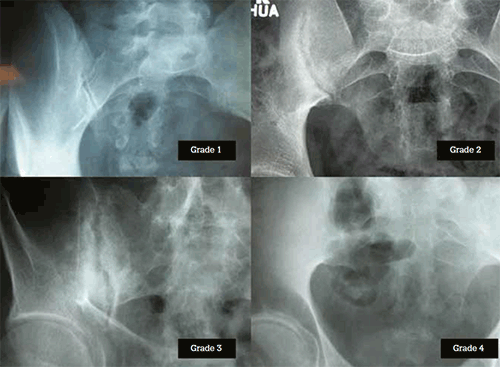

> Radiographic grading of sacroiliac joints.  
> Grade 1: Suspicious changes, not definitive.  
> Grade 2: Small localised areas of *erosions* or *sclerosis*; normal joint space width.  
> Grade 3: Definite changes of erosions, sclerosis, *narrowing or partial fusion*.  
> Grade 4: **Complete fusion**  
> [Source](https://www.racgp.org.au/afp/2013/november/ankylosing-spondylitis)  
> **Syndesmophytes** and changes of spondylitis in the *spine*, which are most often detected in more *longstanding disease*.  
> A **syndesmophyte** is a bony growth *originating inside a ligament*, commonly seen in the ligaments of the spine, specifically the *ligaments in the intervertebral joints* leading to *fusion of vertebrae*.  
> **Inflammatory** osteoproliferative lesions in the spine are called **syndesmophytes** (marginal and non-marginal), and **degenerative** osteoproliferative lesions are called osteophytes. **Syndesmophytes are more vertically oriented than osteophytes.**

> [!INFO] Syndesmophytes are only seen in
> - ankylosing spondylitis
> - ochronosis
> - fluorosis
> - reactive arthritis
> - psoriatic arthritis  
>   Note: NOT in rheumatoid arthritis.

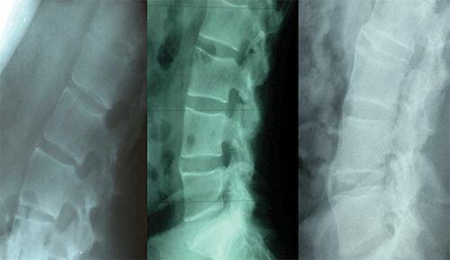

>   Lumbar spine changes in AS. A) Shiny corners and erosions. B) Early syndesmophytes C) Spinal fusion or ankylosis  
>   [Source](https://www.racgp.org.au/afp/2013/november/ankylosing-spondylitis)

# Radiographic features of various arthropathies

[output not shown]

- **Punched out bone cysts** on X ray.

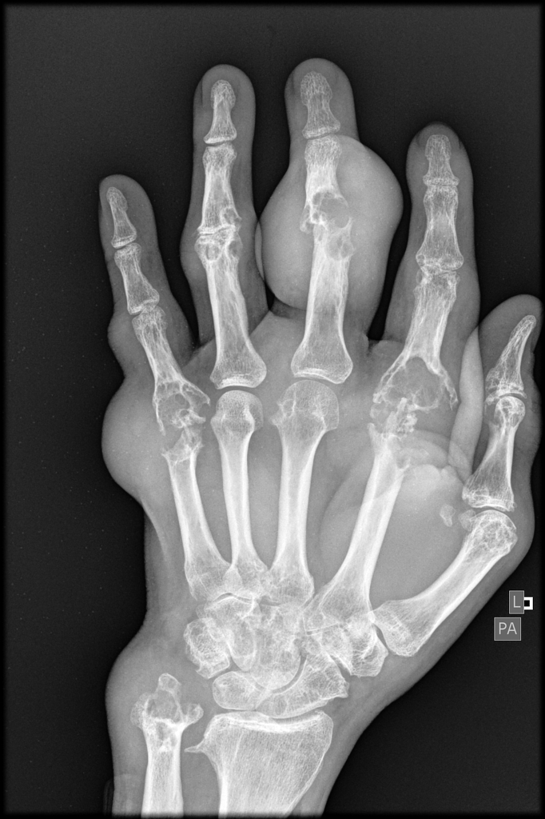

> CPPD disease can be differentiated from gout on ultrasound given that **echogenic monosodium urate** crystals **line the surface of** articular cartilage, whereas **echogenic CPPD calcifications** are located **within the cartilage** itself*

> [!INFO] Chondrocalcinosis  
> #chondrocalcinosis #2015MCQ-APR/Q31  
> Deposition of calcium in the articular cartilates (chondrocalcinosis) is very common in CPPD. (almost so much that it's synonymous). However, it is NOT present in all CPPD and not all chondrocalcinosis is due to CPPD. Therefore, chondrocalcinosis is **not diagnostic** of CPPD.
- Gastrin secreting tumours.
- Most commonly (80%) located in to the duodenum.
- Can also originate from the pancreas.
- Commonest symptoms:
  - Abdominal pain
  - Chronic diarrhoea - excess acid passes into the distal GI tract and causes various things (like villous atrophy and malabsorption)
- Associated with MEN1
- Cause peptic ulcers; most commonly solitary ulcers in the first part of the duodenum.

**Pathology**

- There is hypertrophy of gastric mucosa secondary to gastrin.  
  **Diagnosis**:
- Measurement of fasting serum gastrin levels and gastric pH.
- Secretin stimulation test. (paradoxically increases gastrin levels)
- Calcium infusion study is a last line test for those with negative secretin stimulation test with strong clinical suspicion of gastrinoma. (calcium infusion also *increases* serum gastrin level) [Source](https://pubmed.ncbi.nlm.nih.gov/2572194/)
- Calcitonin levels are also elevated in zollinger ellison syndrome.